# Mouse_modeling

LeZhang

6/13/2018

# Setup

This is a automatic report script. Users only need to place this Rmd to the same folder as you store mouse training data and knit. A html report will be generated.

You need to specify your go/nogo ratio below

```r
goRatio = 0.50
```

# Data structure

## Mice from different days analyzed

```
## # A tibble: 24 x 3
## # Groups:   mouseID [3]
##    date       mouseID    day
##    <date>     <fct>    <dbl>
##  1 2017-11-30 Gi-3         1
##  2 2017-12-01 Gi-3         2
##  3 2017-12-02 Gi-3         3
##  4 2017-12-03 Gi-3         4
##  5 2017-12-05 Gi-3         5
##  6 2017-12-06 Gi-3         6
##  7 2017-12-07 Gi-3         7
##  8 2017-12-08 Gi-3         8
##  9 2017-11-11 JIMS1023     1
## 10 2017-11-12 JIMS1023     2
## # ... with 14 more rows
```

## Structure of data set

```
## [1] 7855   12
```

```
##  [1] "go_trials"        "nogo_trials"      "hit_trials"
##  [4] "miss_trials"      "cr_trials"        "fa_trials"
##  [7] "premature_trials" "InjectOrNot"      "TrialNum"
## [10] "lick_timestamps"  "mouseID"          "day"
```

## clean

Check structure again after removing `NA`

```
## [1] 7855   12
```

```
## # A tibble: 15 x 3
## # Groups:   B.type [?]
##    B.type    mouseID      n
##    <chr>     <fct>    <int>
##  1 cr        Gi-3       678
##  2 cr        JIMS1023   673
##  3 cr        JIMS1025   649
##  4 fa        Gi-3       320
##  5 fa        JIMS1023   220
##  6 fa        JIMS1025   438
##  7 hit       Gi-3       796
##  8 hit       JIMS1023   742
##  9 hit       JIMS1025   950
## 10 mis       Gi-3       222
## 11 mis       JIMS1023   165
## 12 mis       JIMS1025    84
## 13 premature Gi-3       582
## 14 premature JIMS1023   496
## 15 premature JIMS1025   840
```

# Basic stats of in plots

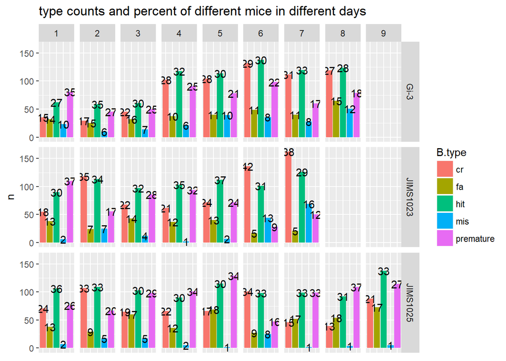

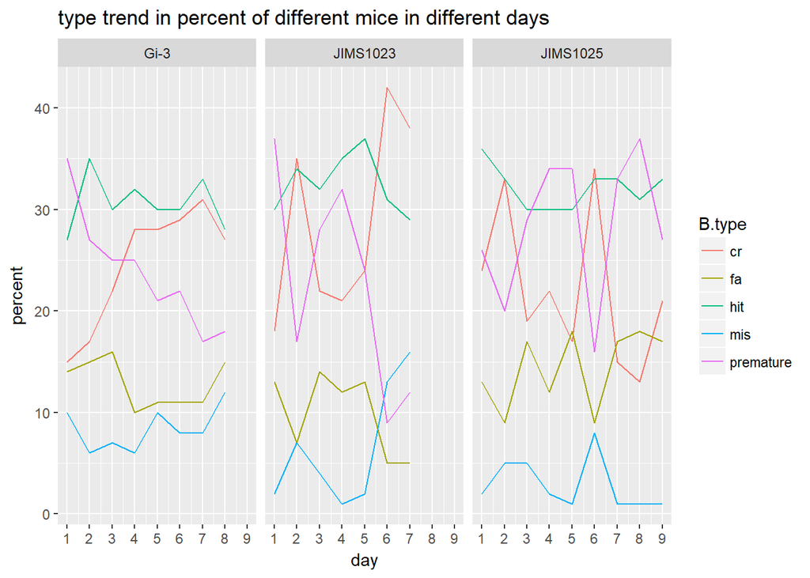

```
## # A tibble: 120 x 5
## # Groups:   mouseID, day [24]
##    B.type mouseID    day     n percent
##    <chr>  <fct>    <dbl> <int>   <dbl>
##  1 cr     Gi-3         1    35      15
##  2 cr     Gi-3         2    29      17
##  3 cr     Gi-3         3    45      22
##  4 cr     Gi-3         4   102      28
##  5 cr     Gi-3         5   104      28
##  6 cr     Gi-3         6   132      29
##  7 cr     Gi-3         7   112      31
##  8 cr     Gi-3         8   119      27
##  9 cr     JIMS1023     1    55      18
## 10 cr     JIMS1023     2   118      35
## # ... with 110 more rows
```

> Add one column: correct.b - correct behavior, correct 1, fail 0

> Add one column: correct.b.ma - correct behavior and premature, correct 1, fail -1, premature 0

# Go : NoGo Ratio & Correct Ratio

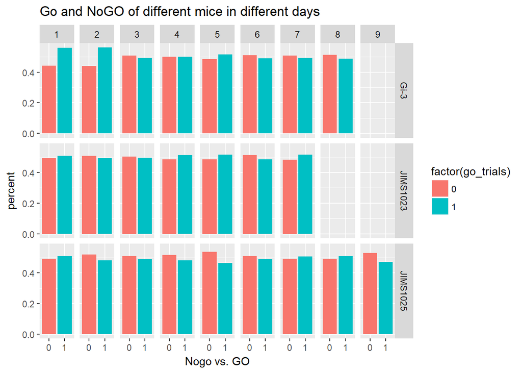

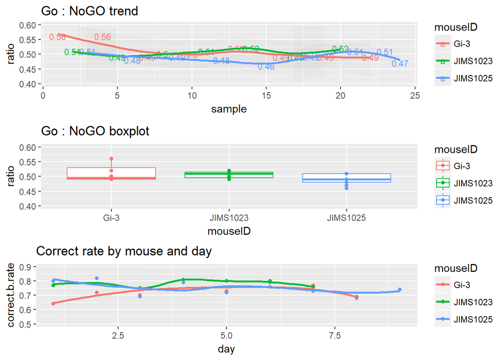

```
## # A tibble: 3 x 9
## # Groups:   mouseID [3]
##   mouseID  estimate statistic  p.value parameter conf.low conf.high method
##   <fct>       <dbl>     <dbl>    <dbl>     <dbl>    <dbl>     <dbl> <fct>
## 1 Gi-3        0.512      46.7 5.41e-10         7    0.487     0.538 One S~
## 2 JIMS1023    0.506     105.  4.99e-11         6    0.494     0.517 One S~
## 3 JIMS1025    0.489      80.0 6.65e-13         8    0.475     0.503 One S~
## # ... with 1 more variable: alternative <fct>
```

## 95% interval of Go: NoGo = 0.5

based on 10 times max days( 9 days) random sampling with 350 trials per day, the 95 confidence intervel is as below:

```
##    estimate statistic       p.value parameter  conf.low conf.high
## 1 0.4997778  167.4343 4.910588e-113        89 0.4938468 0.5057087
##              method alternative
## 1 One Sample t-test   two.sided
```

# Modeling

All models tested with 25 fold bootstrap validations.

## Fit data to a logistic model

While buiding the model, prematures are removed, the previous go/nogo number is treated as previous trial.

# Let’s do the shuffle before ploting

Shuffle 10 times and take the mean

Code maybe hiding in final report

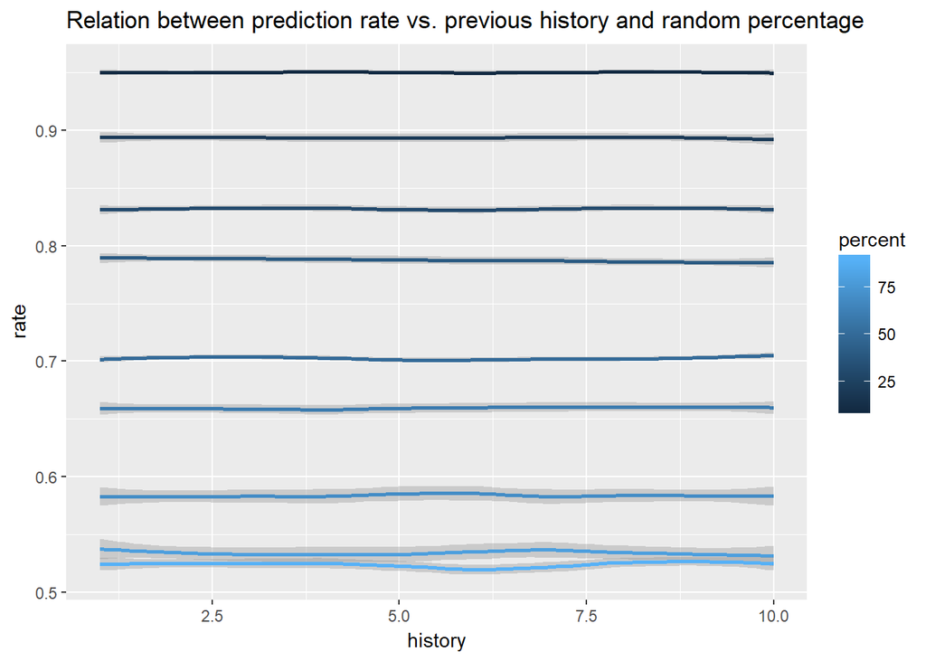

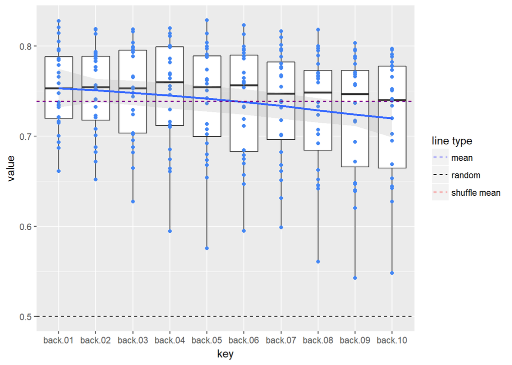

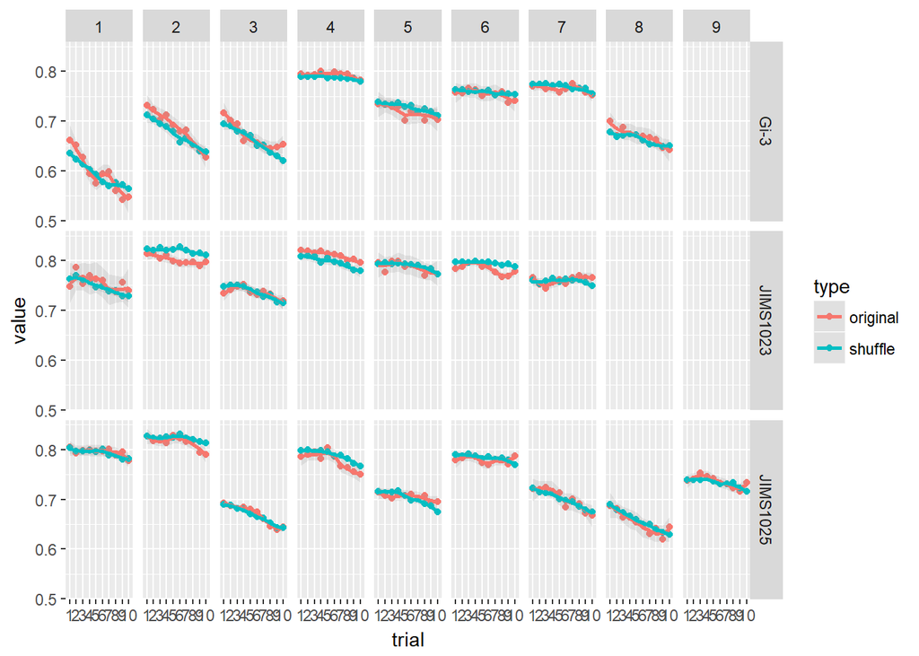

## Fit data to a KNN model

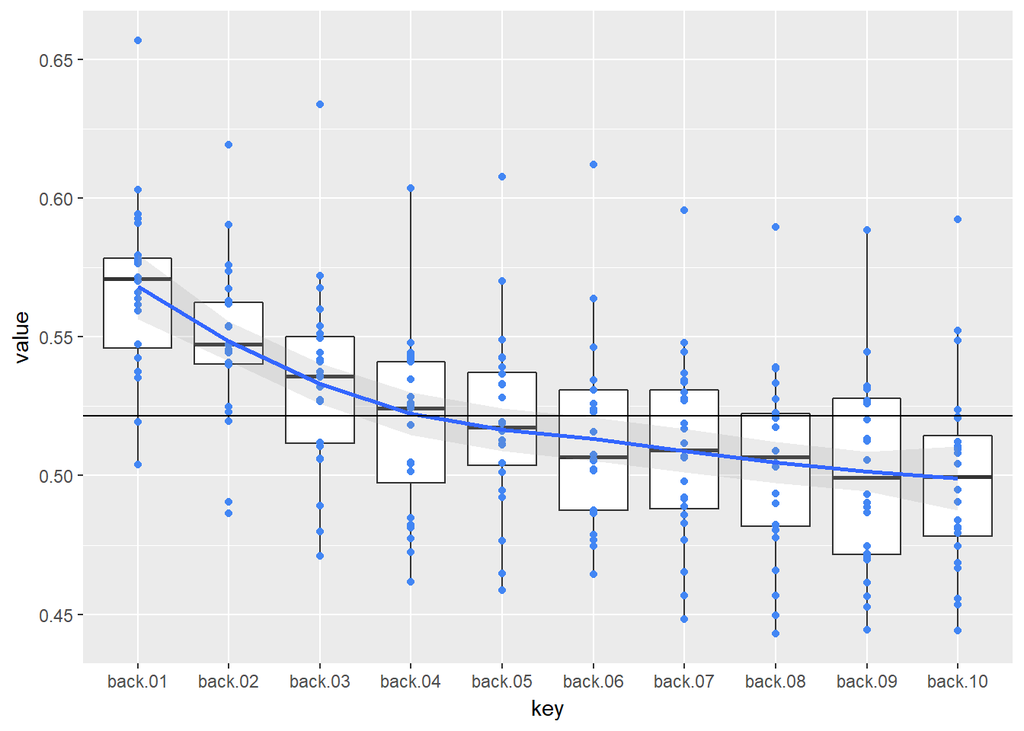

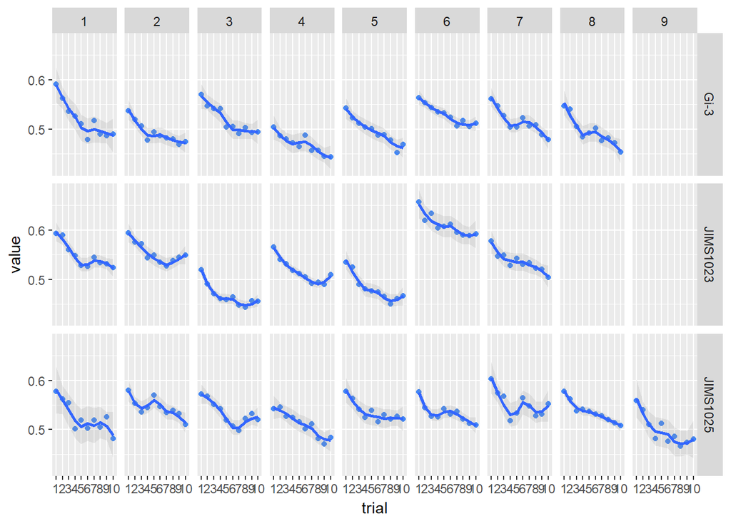

Fit Knn model with correct, not correct and pre-mature

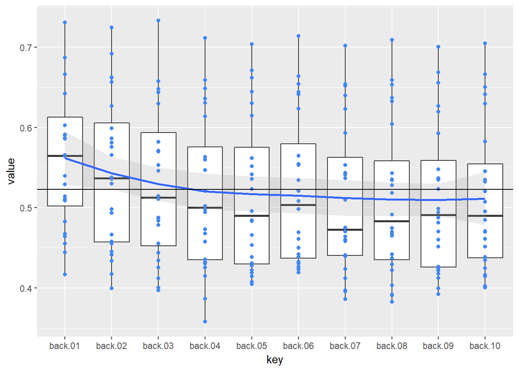

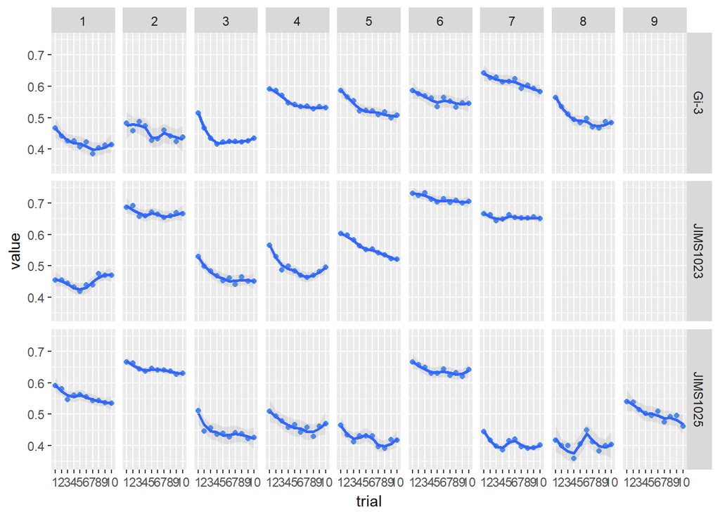

## correlation

corplot of each variable used agianst ‘if correct behavior’ as the y variable.

In the following plot, `correct.b.ma` is the response variable.

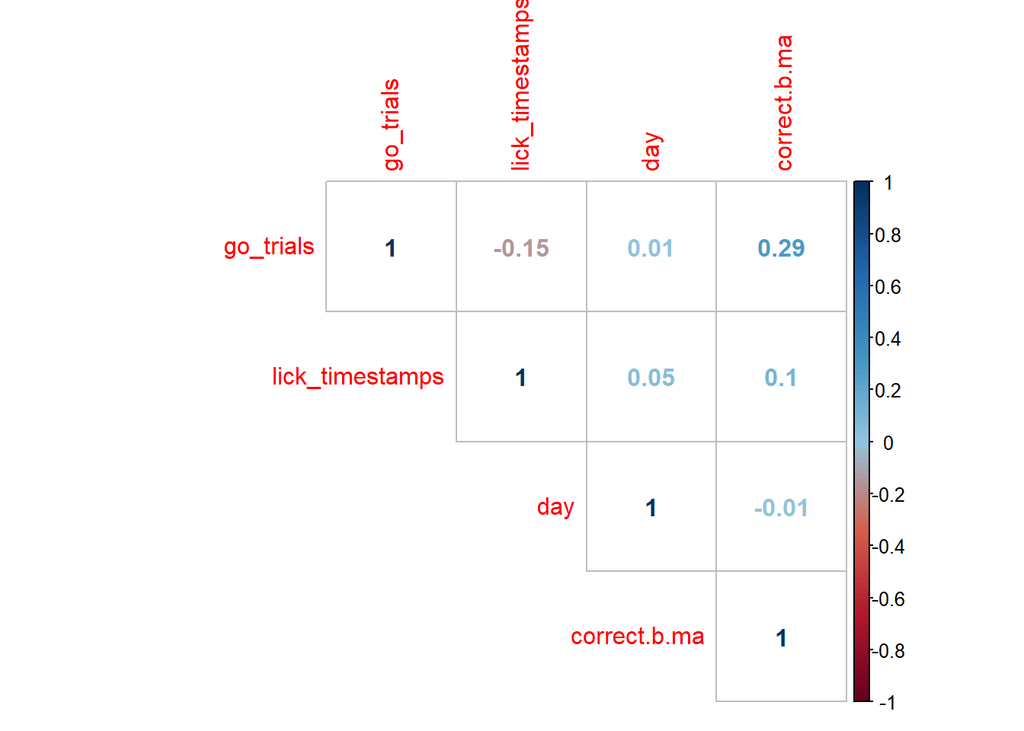

# Ignore below

## Fit a linear model of `correct.b.ma`

## A logistic model classification with `correct.b`

The max outcome from glm is 2: 0 & 1; so can’t use `correct.b.ma`. Prematures are removed

## KNN model with `B.type`

Use KNN to fit b.type which can handle more than 2 types.